# Machine Learning Project

Richard A Morrisey

5/10/2016

```r
library(knitr)
opts_chunk$set(cache=FALSE)
```

## Introduction

This study will attempt to use machine learning algorithms using data collected by [Veloso, E. et.al.][WLE]. In which they developed a model to predict good vs. poor weight training form using motion sensors. The sensors were attached to the belt, forearm, arm, and dumbbell of six subjects as they performed dumbell lifts in 5 different ways.

| Classe | Activity |
| --- | --- |
| A | Correct way |
| B | throwing the elbows to the front |
| C | lifting the dumbbell only halfway |
| D | lowering the dumbbell only halfway |
| E | throwing the hips to the front |

Participants:

- adelmo
- calitos
- charles
- eurico
- jeremy
- pedro

Here we will independently analyze the data.

## Data

Here is how and when the data was retrieved:

```r
onetimeDownload <- function(url) {
        fileName <- sub(".*/(.*)$", "\\1", url)
        if ( !file.exists(fileName) ) {
                download.file(url, destfile=fileName, method="curl")
        } else {
                file.info(fileName)[,c("size", "mtime")]
        }
}

url1 <- "https://d396qusza40orc.cloudfront.net/predmachlearn/pml-training.csv"
url2 <- "https://d396qusza40orc.cloudfront.net/predmachlearn/pml-testing.csv"
dataSources <- list(url1, url2)
lapply(dataSources, onetimeDownload)
```

```
## [[1]]
##                      size               mtime
## pml-training.csv 12202745 2016-06-05 11:57:06
##
## [[2]]
##                  size               mtime
## pml-testing.csv 15113 2016-06-05 11:57:06
```

## Exploratory Analysis

This is what the data looks like:

```r
pmlTraining <- read.csv("pml-training.csv")
pmlTesting <- read.csv("pml-testing.csv")
summary(pmlTraining$user_name); summary(pmlTraining$classe)
```

```
##   adelmo carlitos  charles   eurico   jeremy    pedro
##     3892     3112     3536     3070     3402     2610
```

```
##    A    B    C    D    E
## 5580 3797 3422 3216 3607
```

```r
nrow(pmlTesting)
```

```
## [1] 20
```

Note that the data are not balanced with respect to the user or activity. Also note thet there are only 20 observations in the testing set. As a result, we could not be expected to train based on a time series because any model would be making use of a time sequence and we would not have that information in the test data. The raw data cosissta of the following:

```r
var_names <- names(pmlTraining)
filter_pattern1 <- "X|timestamp|window|name|classe"
filter_pattern2 <- "^(min_|max_|avg_|var_|stddev_|kurtosis_|skewness_|amplitude_)"
filter_pattern3 <- "^(pitch|yaw|roll|total)"
filter_pattern <- paste(filter_pattern1, filter_pattern2, filter_pattern3, sep="|")
raw_readings <- var_names[-grep(filter_pattern, var_names)]
raw_readings
```

```
##  [1] "gyros_belt_x"      "gyros_belt_y"      "gyros_belt_z"
##  [4] "accel_belt_x"      "accel_belt_y"      "accel_belt_z"
##  [7] "magnet_belt_x"     "magnet_belt_y"     "magnet_belt_z"
## [10] "gyros_arm_x"       "gyros_arm_y"       "gyros_arm_z"
## [13] "accel_arm_x"       "accel_arm_y"       "accel_arm_z"
## [16] "magnet_arm_x"      "magnet_arm_y"      "magnet_arm_z"
## [19] "gyros_dumbbell_x"  "gyros_dumbbell_y"  "gyros_dumbbell_z"
## [22] "accel_dumbbell_x"  "accel_dumbbell_y"  "accel_dumbbell_z"
## [25] "magnet_dumbbell_x" "magnet_dumbbell_y" "magnet_dumbbell_z"
## [28] "gyros_forearm_x"   "gyros_forearm_y"   "gyros_forearm_z"
## [31] "accel_forearm_x"   "accel_forearm_y"   "accel_forearm_z"
## [34] "magnet_forearm_x"  "magnet_forearm_y"  "magnet_forearm_z"
```

It’s difficult to get the meaning of the actual timestamps. The sampling rate is 45 Hz so the period should be 1/45 = 0.022 seconds per sample. However, looking at the time stamp deltas, it does not look like the time was collected very uniformly. Let’s look at the first trial. Below is a look at Carlitos A. Ultimately it would be nice to fit splines to the data and resample. However, we will try it a simpler way first.

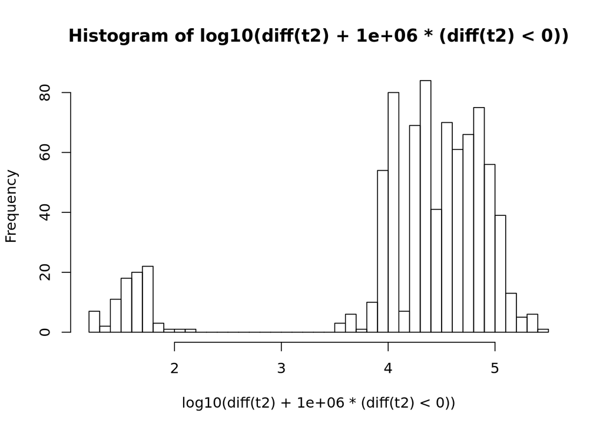

```r
library("ggplot2")

timings <- subset(pmlTraining, user_name=="carlitos" & classe=="A", select=c(user_name,raw_timestamp_part_1, raw_timestamp_part_2, classe))
t1 <- timings$raw_timestamp_part_1
t2 <- timings$raw_timestamp_part_2

hist(log10( diff(t2) + 1000000 * (diff(t2) < 0) ) , breaks=50)
```

```r
# This function might get used if we want to use time
time_calcs <- function(timevals) {
    dt <- diff(timevals)
    delta_t <- dt  + 1000000 * (dt < 0)
    delta_t <- c(0, delta_t)
    running_t <- cumsum(delta_t)
    list(delta_t=delta_t, running_t=running_t)
}
```

So now let’s rebuild the data frame in a way that we like.

```r
library(dplyr)
```

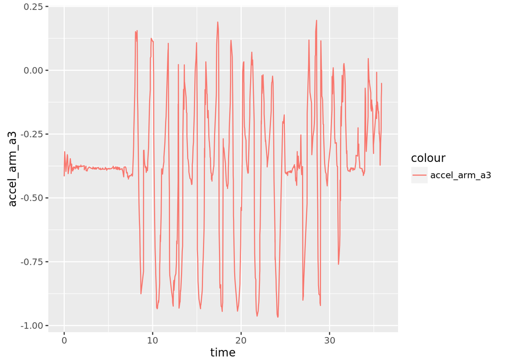

```r
cleanTraining <- pmlTraining %>%
    select(user_name, classe, raw_timestamp_part_2,
           accel_arm_x, accel_arm_y, accel_arm_z,
           gyros_arm_x, gyros_arm_y, gyros_arm_z,
           magnet_arm_x, magnet_arm_y, magnet_arm_z,
           accel_belt_x, accel_belt_y, accel_belt_z,
           gyros_belt_x, gyros_belt_y, gyros_belt_z,
           magnet_belt_x, magnet_belt_y, magnet_belt_z,
           accel_dumbbell_x, accel_dumbbell_y, accel_dumbbell_z,
           gyros_dumbbell_x, gyros_dumbbell_y, gyros_dumbbell_z,
           magnet_dumbbell_x, magnet_dumbbell_y, magnet_dumbbell_z,
           accel_forearm_x, accel_forearm_y, accel_forearm_z,
           gyros_forearm_x, gyros_forearm_y, gyros_forearm_z,
           magnet_forearm_x, magnet_forearm_y, magnet_forearm_z) %>%
    group_by(user_name, classe) %>%
    mutate(deltat=time_calcs(raw_timestamp_part_2)$delta_t) %>%
    mutate(time=time_calcs(raw_timestamp_part_2)$running_t/1.0e6) %>%
    mutate(accel_arm_mag=sqrt(accel_arm_x^2 + accel_arm_y^2 + accel_arm_z^2)) %>%
    mutate(accel_arm_a1=accel_arm_x/accel_arm_mag) %>%
    mutate(accel_arm_a2=accel_arm_y/accel_arm_mag) %>%
    mutate(accel_arm_a3=accel_arm_z/accel_arm_mag) %>%
    data.frame()

sample_set <- subset(cleanTraining, user_name == "eurico" & classe == "A", select=c(user_name, classe, time, deltat, accel_arm_mag, accel_arm_a1, accel_arm_a2, accel_arm_a3))
fit <- loess(accel_arm_mag ~ time, sample_set, span=.05)
pred <- predict(fit, sample_set$time)
ggplot(sample_set, aes(time)) +
    #geom_line(aes(y=pred, color="accel_arm_mag")) +
    #geom_line(aes(y=accel_arm_a1, color="accel_arm_a1"))
    #geom_line(aes(y=accel_arm_a2, color="accel_arm_a2"))
    geom_line(aes(y=accel_arm_a3, color="accel_arm_a3"))
```

## Actual Analysis

So seems like we can do a lot of complicated things let’s just use the machine learning libraries straight up.

```r
library(caret)
# This function is the vector magnitude in cartesian coordinates.
vec_mag <- function(comp) sqrt(comp[1]^2 + comp[2]^2 + comp[3]^2)

trainingData <- pmlTraining %>%
    select(user_name, classe, matches("^(accel|gyros|magnet)_.*_(x|y|z)$")) %>%
    mutate(accel_arm_mag = accel_arm_x^2 + accel_arm_y ^2 + accel_arm_z^2) %>%
    mutate(accel_arm_a1 = accel_arm_x / accel_arm_mag) %>%
    mutate(accel_arm_a2 = accel_arm_y / accel_arm_mag) %>%
    mutate(accel_arm_a3 = accel_arm_z / accel_arm_mag) %>%
    mutate(accel_belt_mag = accel_belt_x^2 + accel_belt_y^2 + accel_belt_z^2) %>%
    mutate(accel_belt_a1 = accel_belt_x / accel_belt_mag) %>%
    mutate(accel_belt_a2 = accel_belt_y / accel_belt_mag) %>%
    mutate(accel_belt_a3 = accel_belt_z / accel_belt_mag) %>%
    mutate(accel_dumbbell_mag = accel_dumbbell_x^2+ accel_dumbbell_y^2 +
                                        accel_dumbbell_z^2) %>%
    mutate(accel_dumbbell_a1 = accel_dumbbell_x / accel_dumbbell_mag) %>%
    mutate(accel_dumbbell_a2 = accel_dumbbell_y / accel_dumbbell_mag) %>%
    mutate(accel_dumbbell_a3 = accel_dumbbell_z / accel_dumbbell_mag) %>%
    mutate(accel_forearm_mag = accel_forearm_x^2 + accel_forearm_y^2 +
                                       accel_forearm_z^2) %>%
    mutate(accel_forearm_a1 = accel_forearm_x / accel_forearm_mag) %>%
    mutate(accel_forearm_a2 = accel_forearm_y / accel_forearm_mag) %>%
    mutate(accel_forearm_a3 = accel_forearm_z / accel_forearm_mag)
```

```r
set.seed(12221)
training <- data.frame()
for (user_level in levels(trainingData$user_name)) {
    for (classe in levels(trainingData$classe)) {
        chunk <- trainingData %>%
            filter(user_name == user_level, classe == classe) %>%
            sample_frac(size = 0.15)
        training <- merge(training, chunk, all = TRUE)
    }
}

inTrain <- createDataPartition(training$classe, p=.6, list=FALSE)
cvTraining <- training[inTrain,]
cvTestValid <- training[-inTrain,]

inTrain <- createDataPartition(cvTestValid$classe, p=.5, list=FALSE)
cvTesting <- cvTestValid[inTrain,]
cvValidate <- cvTestValid[-inTrain,]
```

```r
set.seed(62433)
ppObject <- preProcess(cvTraining, method=c("pca"), thresh=0.8)
ppObject
```

```
## Created from 6384 samples and 54 variables
##
## Pre-processing:
##   - centered (52)
##   - ignored (2)
##   - principal component signal extraction (52)
##   - scaled (52)
##
## PCA needed 16 components to capture 80 percent of the variance
```

```r
# Run it through again to actually obtain the data frame
cvTrainingPCA <- predict(ppObject, newdata=cvTraining)
cvTestingPCA <- predict(ppObject, newdata=cvTesting)
cvValidatePCA <- predict(ppObject, newdata=cvValidate)
```

```r
ctrl <- trainControl(method="cv",
                     number=3,
                     repeats=1)
rfFit <- train(classe ~ ., data=cvTrainingPCA, method="rf", trControl = ctrl, verbose=FALSE)
rfFit
```

```
## Random Forest
##
## 6384 samples
##   17 predictors
##    5 classes: 'A', 'B', 'C', 'D', 'E'
##
## No pre-processing
## Resampling: Cross-Validated (3 fold)
## Summary of sample sizes: 4257, 4255, 4256
## Resampling results across tuning parameters:
##
##   mtry  Accuracy   Kappa
##    2    0.8765631  0.8436171
##   11    0.8764078  0.8434573
##   21    0.8670102  0.8315042
##
## Accuracy was used to select the optimal model using  the largest value.
## The final value used for the model was mtry = 2.
```

```r
rfPred <- predict(rfFit, newdata=cvTestingPCA)
confusionMatrix(rfPred, cvTesting$classe)
```

```
## Confusion Matrix and Statistics
##
##           Reference
## Prediction   A   B   C   D   E
##          A 565  20  19  15   5
##          B   7 358  16   2  10
##          C  19  20 330  25   9
##          D  15   4   7 292   7
##          E   1   9   3   5 365
##
## Overall Statistics
##
##                Accuracy : 0.8976
##                  95% CI : (0.8839, 0.9101)
##     No Information Rate : 0.2852
##     P-Value [Acc > NIR] : < 2.2e-16
##
##                   Kappa : 0.8702
##  Mcnemar's Test P-Value : 0.008895
##
## Statistics by Class:
##
##                      Class: A Class: B Class: C Class: D Class: E
## Sensitivity            0.9308   0.8710   0.8800   0.8614   0.9217
## Specificity            0.9612   0.9796   0.9584   0.9816   0.9896
## Pos Pred Value         0.9054   0.9109   0.8189   0.8985   0.9530
## Neg Pred Value         0.9721   0.9695   0.9739   0.9739   0.9822
## Prevalence             0.2852   0.1931   0.1762   0.1593   0.1861
## Detection Rate         0.2655   0.1682   0.1551   0.1372   0.1715
## Detection Prevalence   0.2932   0.1847   0.1894   0.1527   0.1800
## Balanced Accuracy      0.9460   0.9253   0.9192   0.9215   0.9557
```

```r
ctrl <- trainControl(method="cv",
                     number=10,
                     repeats=1)
gbmFit <- train(classe ~ ., data=cvTrainingPCA, method="gbm", trControl = ctrl, verbose=FALSE)
gbmFit
```

```
## Stochastic Gradient Boosting
##
## 6384 samples
##   17 predictors
##    5 classes: 'A', 'B', 'C', 'D', 'E'
##
## No pre-processing
## Resampling: Cross-Validated (10 fold)
## Summary of sample sizes: 5744, 5746, 5747, 5746, 5745, 5746, ...
## Resampling results across tuning parameters:
##
##   interaction.depth  n.trees  Accuracy   Kappa
##   1                   50      0.5247465  0.3851598
##   1                  100      0.5742415  0.4555565
##   1                  150      0.5982075  0.4878837
##   2                   50      0.6127777  0.5051439
##   2                  100      0.6651046  0.5742158
##   2                  150      0.6964301  0.6145950
##   3                   50      0.6586712  0.5656060
##   3                  100      0.7166402  0.6402311
##   3                  150      0.7435720  0.6747571
##
## Tuning parameter 'shrinkage' was held constant at a value of 0.1
##
## Tuning parameter 'n.minobsinnode' was held constant at a value of 10
## Accuracy was used to select the optimal model using  the largest value.
## The final values used for the model were n.trees = 150,
##  interaction.depth = 3, shrinkage = 0.1 and n.minobsinnode = 10.
```

```r
gbmPred <- predict(gbmFit, newdata=cvTestingPCA, preProcess=ppObject)
confusionMatrix(gbmPred, cvTesting$classe)
```

```
## Confusion Matrix and Statistics
##
##           Reference
## Prediction   A   B   C   D   E
##          A 502  52  56  41  19
##          B  17 277  37   7  24
##          C  42  37 265  28  28
##          D  37  19  11 250  23
##          E   9  26   6  13 302
##
## Overall Statistics
##
##                Accuracy : 0.75
##                  95% CI : (0.731, 0.7683)
##     No Information Rate : 0.2852
##     P-Value [Acc > NIR] : < 2.2e-16
##
##                   Kappa : 0.6826
##  Mcnemar's Test P-Value : 5.829e-08
##
## Statistics by Class:
##
##                      Class: A Class: B Class: C Class: D Class: E
## Sensitivity            0.8270   0.6740   0.7067   0.7375   0.7626
## Specificity            0.8895   0.9505   0.9230   0.9497   0.9688
## Pos Pred Value         0.7493   0.7652   0.6625   0.7353   0.8483
## Neg Pred Value         0.9280   0.9241   0.9363   0.9502   0.9470
## Prevalence             0.2852   0.1931   0.1762   0.1593   0.1861
## Detection Rate         0.2359   0.1302   0.1245   0.1175   0.1419
## Detection Prevalence   0.3148   0.1701   0.1880   0.1598   0.1673
## Balanced Accuracy      0.8583   0.8122   0.8148   0.8436   0.8657
```

```r
ctrl <- trainControl(method="cv",
                     number=25,
                     repeats=1)
ldaFit <- train(classe ~ ., data=cvTrainingPCA, method="lda", trControl= ctrl, verbose=FALSE)
ldaFit
```

```
## Linear Discriminant Analysis
##
## 6384 samples
##   17 predictors
##    5 classes: 'A', 'B', 'C', 'D', 'E'
##
## No pre-processing
## Resampling: Cross-Validated (25 fold)
## Summary of sample sizes: 6129, 6128, 6129, 6130, 6127, 6129, ...
## Resampling results:
##
##   Accuracy   Kappa
##   0.4849801  0.3402313
##
##
```

```r
ldaPred <- predict(ldaFit, newdata=cvTestingPCA)
confusionMatrix(ldaPred, cvTesting$classe)
```

```
## Confusion Matrix and Statistics
##
##           Reference
## Prediction   A   B   C   D   E
##          A 414 118 164  86  59
##          B  50 175  67  60  78
##          C  58  26  77  14  28
##          D  78  53  51 150  35
##          E   7  39  16  29 196
##
## Overall Statistics
##
##                Accuracy : 0.4756
##                  95% CI : (0.4542, 0.497)
##     No Information Rate : 0.2852
##     P-Value [Acc > NIR] : < 2.2e-16
##
##                   Kappa : 0.3267
##  Mcnemar's Test P-Value : < 2.2e-16
##
## Statistics by Class:
##
##                      Class: A Class: B Class: C Class: D Class: E
## Sensitivity            0.6820  0.42579  0.20533  0.44248  0.49495
## Specificity            0.7193  0.85149  0.92812  0.87870  0.94746
## Pos Pred Value         0.4923  0.40698  0.37931  0.40872  0.68293
## Neg Pred Value         0.8500  0.86101  0.84519  0.89267  0.89136
## Prevalence             0.2852  0.19314  0.17622  0.15930  0.18609
## Detection Rate         0.1945  0.08224  0.03618  0.07049  0.09211
## Detection Prevalence   0.3952  0.20207  0.09539  0.17246  0.13487
## Balanced Accuracy      0.7007  0.63864  0.56673  0.66059  0.72120
```

```r
# Now use the training data to create a stacked model.
# in stacked Analysis, the predictedt values of the previous models are the
# covariates of a meta-model.
#
classe <- cvTraining$classe
rfPred <- predict(rfFit, newdata=cvTrainingPCA)
gbmPred<- predict(gbmFit, newdata=cvTrainingPCA)
ldaPred <- predict(ldaFit, newdata=cvTrainingPCA)
stackedTrain <- data.frame(classe, rfPred, gbmPred, ldaPred)
stackedFit <- train(classe ~ ., data=stackedTrain, method="gbm", verbose=FALSE)
```

```r
# Now use the training data to create a stacked model.
# in stacked Analysis, the predictedt values of the previous models are the
# covariates of a meta-model.
#
classe <- cvValidate$classe
rfPred <- predict(rfFit, newdata=cvValidatePCA)
gbmPred<- predict(gbmFit, newdata=cvValidatePCA)
ldaPred <- predict(ldaFit, newdata=cvValidatePCA)
stackedTrain <- data.frame(classe, rfPred, gbmPred, ldaPred)
stackedFit <- train(classe ~ ., data=stackedTrain, method="gbm", verbose=FALSE)
predictions <- predict(stackedFit, newData=stackedTrain)
confusionMatrix(predictions, classe)
```

```
## Confusion Matrix and Statistics
##
##           Reference
## Prediction   A   B   C   D   E
##          A 573  17  18  19   3
##          B   8 369  11   2  12
##          C  14  18 338  21  10
##          D  10   2   5 294   6
##          E   2   4   3   3 364
##
## Overall Statistics
##
##                Accuracy : 0.9116
##                  95% CI : (0.8987, 0.9233)
##     No Information Rate : 0.2855
##     P-Value [Acc > NIR] : < 2.2e-16
##
##                   Kappa : 0.8879
##  Mcnemar's Test P-Value : 0.002568
##
## Statistics by Class:
##
##                      Class: A Class: B Class: C Class: D Class: E
## Sensitivity            0.9440   0.9000   0.9013   0.8673   0.9215
## Specificity            0.9625   0.9808   0.9640   0.9871   0.9931
## Pos Pred Value         0.9095   0.9179   0.8429   0.9274   0.9681
## Neg Pred Value         0.9773   0.9762   0.9786   0.9751   0.9823
## Prevalence             0.2855   0.1929   0.1764   0.1595   0.1858
## Detection Rate         0.2695   0.1736   0.1590   0.1383   0.1712
## Detection Prevalence   0.2963   0.1891   0.1886   0.1491   0.1769
## Balanced Accuracy      0.9532   0.9404   0.9327   0.9272   0.9573
```

## Final Answers

```r
library(caret)

testingData <- pmlTesting %>%
    dplyr::select(user_name, matches("^(accel|gyros|magnet)_.*_(x|y|z)$"))  %>%
    mutate(accel_arm_mag = accel_arm_x^2 + accel_arm_y ^2 + accel_arm_z^2) %>%
    mutate(accel_arm_a1 = accel_arm_x / accel_arm_mag) %>%
    mutate(accel_arm_a2 = accel_arm_y / accel_arm_mag) %>%
    mutate(accel_arm_a3 = accel_arm_z / accel_arm_mag) %>%
    mutate(accel_belt_mag = accel_belt_x^2 + accel_belt_y^2 + accel_belt_z^2) %>%
    mutate(accel_belt_a1 = accel_belt_x / accel_belt_mag) %>%
    mutate(accel_belt_a2 = accel_belt_y / accel_belt_mag) %>%
    mutate(accel_belt_a3 = accel_belt_z / accel_belt_mag) %>%
    mutate(accel_dumbbell_mag = accel_dumbbell_x^2+ accel_dumbbell_y^2 +
                                        accel_dumbbell_z^2) %>%
    mutate(accel_dumbbell_a1 = accel_dumbbell_x / accel_dumbbell_mag) %>%
    mutate(accel_dumbbell_a2 = accel_dumbbell_y / accel_dumbbell_mag) %>%
    mutate(accel_dumbbell_a3 = accel_dumbbell_z / accel_dumbbell_mag) %>%
    mutate(accel_forearm_mag = accel_forearm_x^2 + accel_forearm_y^2 +
                                       accel_forearm_z^2) %>%
    mutate(accel_forearm_a1 = accel_forearm_x / accel_forearm_mag) %>%
    mutate(accel_forearm_a2 = accel_forearm_y / accel_forearm_mag) %>%
    mutate(accel_forearm_a3 = accel_forearm_z / accel_forearm_mag)

finalTestingPCA <- predict(ppObject, newdata=testingData)
rfPred <- predict(rfFit, finalTestingPCA)
gbmPred <- predict(gbmFit, finalTestingPCA)
ldaPred <- predict(ldaFit, finalTestingPCA)
stackedDataFinal <- data.frame(rfPred, gbmPred, ldaPred)
predFinal <- predict(stackedFit, newdata=stackedDataFinal)
predFinal
```

```
##  [1] B A C A A E D B A A A C B A E E A B B B
## Levels: A B C D E
```

## Conclusion

Using the most efficient training method is important. I should have just used randomForest heere, that seemsed to give the best accuracy without stacking.

[WLE]: Velloso, E.; Bulling, A.; Gellersen, H.; Ugulino, W.; Fuks, H. **Qualitative Activity Recognition of Weight Lifting Exercises.** Proceedings of 4th International Conference in Cooperation with SIGCHI (Augmented Human ’13) . Stuttgart, Germany: ACM SIGCHI, 2013.